# Sports Analytics A case study in baseball

Olusegun Stephen Omotunde

11/30/2021

# Meet Data: “Hitters”

```r
rm(list = ls())
library(ISLR)
df1 = Hitters
df1 = df1[complete.cases(df1),]

Table = data.frame(table(df1$League), table(df1$Division), table(df1$NewLeague))
names(Table)[1] = "League"
names(Table)[3] = "Division"
names(Table)[5] = "NewLeague"
#View(Table)
Table
```

| League | Freq | Division | Freq.1 | NewLeague | Freq.2 |
| --- | --- | --- | --- | --- | --- |
| A | 139 | E | 129 | A | 141 |
| N | 124 | W | 134 | N | 122 |

```r
str(df1)
```

```
## 'data.frame':    263 obs. of  20 variables:
##  $ AtBat    : int  315 479 496 321 594 185 298 323 401 574 ...
##  $ Hits     : int  81 130 141 87 169 37 73 81 92 159 ...
##  $ HmRun    : int  7 18 20 10 4 1 0 6 17 21 ...
##  $ Runs     : int  24 66 65 39 74 23 24 26 49 107 ...
##  $ RBI      : int  38 72 78 42 51 8 24 32 66 75 ...
##  $ Walks    : int  39 76 37 30 35 21 7 8 65 59 ...
##  $ Years    : int  14 3 11 2 11 2 3 2 13 10 ...
##  $ CAtBat   : int  3449 1624 5628 396 4408 214 509 341 5206 4631 ...
##  $ CHits    : int  835 457 1575 101 1133 42 108 86 1332 1300 ...
##  $ CHmRun   : int  69 63 225 12 19 1 0 6 253 90 ...
##  $ CRuns    : int  321 224 828 48 501 30 41 32 784 702 ...
##  $ CRBI     : int  414 266 838 46 336 9 37 34 890 504 ...
##  $ CWalks   : int  375 263 354 33 194 24 12 8 866 488 ...
##  $ League   : Factor w/ 2 levels "A","N": 2 1 2 2 1 2 1 2 1 1 ...
##  $ Division : Factor w/ 2 levels "E","W": 2 2 1 1 2 1 2 2 1 1 ...
##  $ PutOuts  : int  632 880 200 805 282 76 121 143 0 238 ...
##  $ Assists  : int  43 82 11 40 421 127 283 290 0 445 ...
##  $ Errors   : int  10 14 3 4 25 7 9 19 0 22 ...
##  $ Salary   : num  475 480 500 91.5 750 ...
##  $ NewLeague: Factor w/ 2 levels "A","N": 2 1 2 2 1 1 1 2 1 1 ...
```

- We have 16 continuous variables
- Also, we have 3 categorical variables.

## Full MLR model

```r
mlr1 = lm(Salary ~ . , data = df1)
summary(mlr1)
```

```
##
## Call:
## lm(formula = Salary ~ ., data = df1)
##
## Residuals:
##     Min      1Q  Median      3Q     Max
## -907.62 -178.35  -31.11  139.09 1877.04
##
## Coefficients:
##               Estimate Std. Error t value Pr(>|t|)
## (Intercept)  163.10359   90.77854   1.797 0.073622 .
## AtBat         -1.97987    0.63398  -3.123 0.002008 **
## Hits           7.50077    2.37753   3.155 0.001808 **
## HmRun          4.33088    6.20145   0.698 0.485616
## Runs          -2.37621    2.98076  -0.797 0.426122
## RBI           -1.04496    2.60088  -0.402 0.688204
## Walks          6.23129    1.82850   3.408 0.000766 ***
## Years         -3.48905   12.41219  -0.281 0.778874
## CAtBat        -0.17134    0.13524  -1.267 0.206380
## CHits          0.13399    0.67455   0.199 0.842713
## CHmRun        -0.17286    1.61724  -0.107 0.914967
## CRuns          1.45430    0.75046   1.938 0.053795 .
## CRBI           0.80771    0.69262   1.166 0.244691
## CWalks        -0.81157    0.32808  -2.474 0.014057 *
## LeagueN       62.59942   79.26140   0.790 0.430424
## DivisionW   -116.84925   40.36695  -2.895 0.004141 **
## PutOuts        0.28189    0.07744   3.640 0.000333 ***
## Assists        0.37107    0.22120   1.678 0.094723 .
## Errors        -3.36076    4.39163  -0.765 0.444857
## NewLeagueN   -24.76233   79.00263  -0.313 0.754218
## ---
## Signif. codes:  0 '***' 0.001 '**' 0.01 '*' 0.05 '.' 0.1 ' ' 1
##
## Residual standard error: 315.6 on 243 degrees of freedom
## Multiple R-squared:  0.5461, Adjusted R-squared:  0.5106
## F-statistic: 15.39 on 19 and 243 DF,  p-value: < 2.2e-16
```

### Check linearity assumptions

#### scatter plots for response variable vs. the regressors

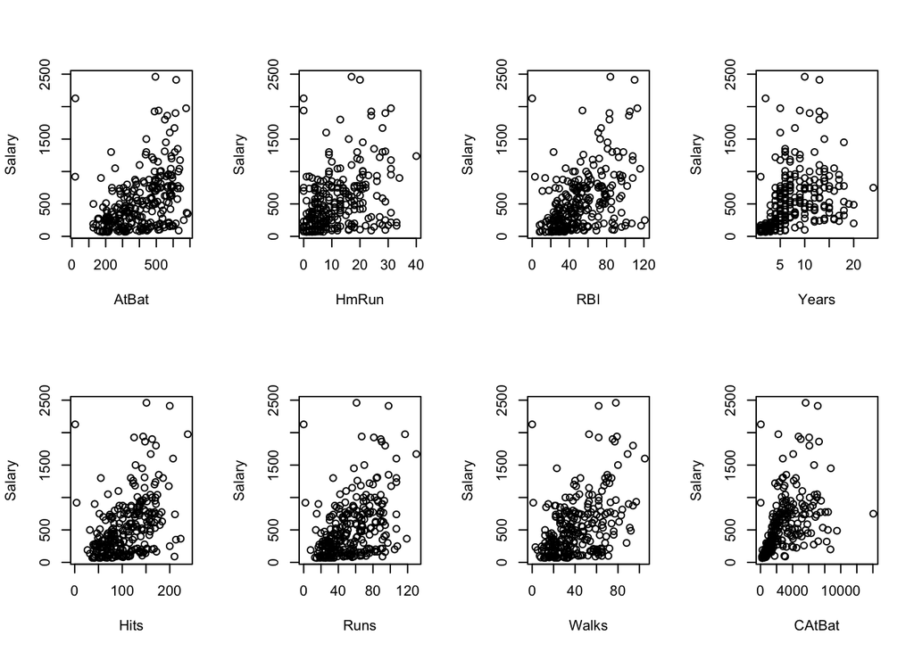

```r
#pairs(df1)
# pairs(df1[ , c(17, 1:4)])
# pairs(df1[ , c(17, 5:8)])
# pairs(df1[ , c(17, 9:12)])
# pairs(df1[ , c(17, 13:16)])

#
par(mfcol = c(2, 4))
plot(df1$AtBat, df1$Salary,
     xlab = "AtBat",
     ylab = "Salary")
plot(df1$Hits, df1$Salary,
     xlab = "Hits",
     ylab = "Salary")
plot(df1$HmRun, df1$Salary,
     xlab = "HmRun",
     ylab = "Salary")
plot(df1$Runs, df1$Salary,
     xlab = "Runs",
     ylab = "Salary")
plot(df1$RBI, df1$Salary,
     xlab = "RBI",
     ylab = "Salary")
plot(df1$Walks, df1$Salary,
     xlab = "Walks",
     ylab = "Salary")
plot(df1$Years, df1$Salary,
     xlab = "Years",
     ylab = "Salary")
plot(df1$CAtBat, df1$Salary,
     xlab = "CAtBat",
     ylab = "Salary")
```

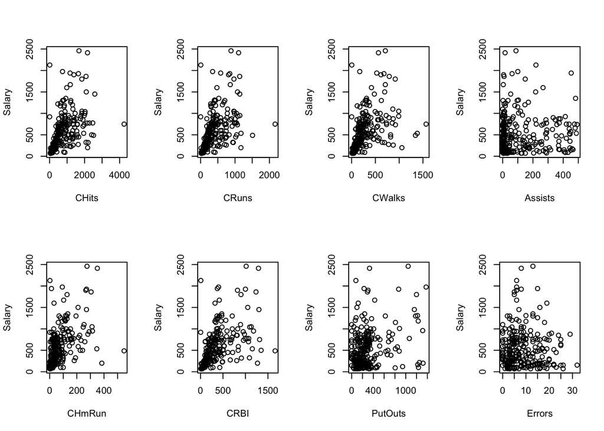

```r
plot(df1$CHits, df1$Salary,
     xlab = "CHits",
     ylab = "Salary")
plot(df1$CHmRun, df1$Salary,
     xlab = "CHmRun",
     ylab = "Salary")
plot(df1$CRuns, df1$Salary,
     xlab = "CRuns",
     ylab = "Salary")
plot(df1$CRBI, df1$Salary,
     xlab = "CRBI",
     ylab = "Salary")
plot(df1$CWalks, df1$Salary,
     xlab = "CWalks",
     ylab = "Salary")
plot(df1$PutOuts, df1$Salary,
     xlab = "PutOuts",
     ylab = "Salary")
plot(df1$Assists, df1$Salary,
     xlab = "Assists",
     ylab = "Salary")
plot(df1$Errors, df1$Salary,
     xlab = "Errors",
     ylab = "Salary")
```

#### interpretation Variables like Years, Runs, Walks, and Assists do not have a linear relationship with the response (Salary)

#### Checking for zero mean and constant variance of error terms

Residual errors vs. the Fitted values

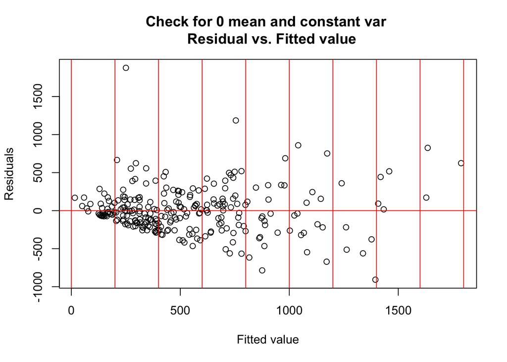

```r
plot(mlr1$fitted.values, mlr1$residuals,
     xlab = "Fitted value",
     ylab = "Residuals",
     main = "Check for 0 mean and constant var \n  Residual vs. Fitted value")
list1 = seq(0,2000,200)
abline(h=0, v = list1, col="red")
```

#### Comments  
- If we imagine some vertical strips we realize that the average mean is not zero  
- If we scan the plot from left to right that variance is not constant.

```r
#row_num <- c(1:nrow(Dat))
# sort_x1 <- sort(Dat$hp, index.return=TRUE)
# plot(row_num, mlr1$residuals[sort_x1$ix],
# main = "Check for independence \n Residuals sorted by hp")
# abline(h=0)
```

#### Normal Probability Plot

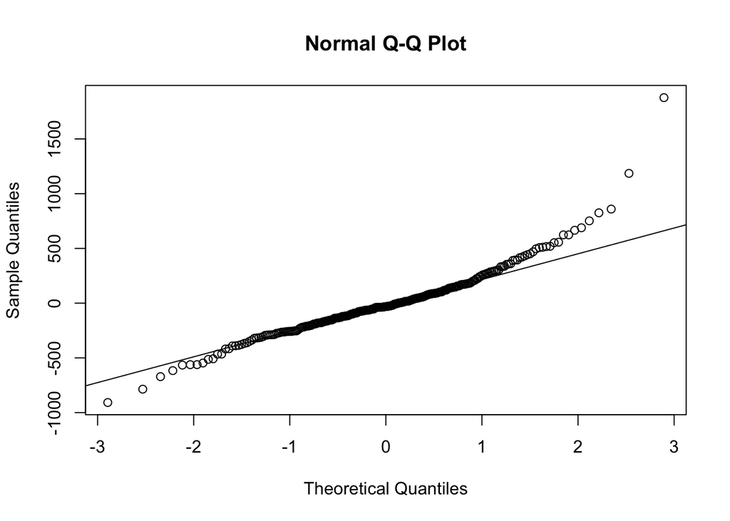

```r
qqnorm(mlr1$residuals)
qqline(mlr1$residuals)
```

#### Comments  
the dataset is not normal, there are some point that far away from from the straight line.

#### Perform Shapiro-Wilk test for normality

```r
shapiro.test(mlr1$residuals)
```

```
##
##  Shapiro-Wilk normality test
##
## data:  mlr1$residuals
## W = 0.92899, p-value = 6.602e-10
```

#### Comments

According to the Shapiro-Wilk test, the p-value is 6.602e-10 which is less than 0.05. So we reject the null hypothesis and conclude that the dataset does not follow a normal distribution.

### VIF

```r
library(car)
vif(mlr1)
```

```
##      AtBat       Hits      HmRun       Runs        RBI      Walks      Years
##  22.944366  30.281255   7.758668  15.246418  11.921715   4.148712   9.313280
##     CAtBat      CHits     CHmRun      CRuns       CRBI     CWalks     League
## 251.561160 502.954289  46.488462 162.520810 131.965858  19.744105   4.134115
##   Division    PutOuts    Assists     Errors  NewLeague
##   1.075398   1.236317   2.709341   2.214543   4.099063
```

#### Comments

The model suffers from high multicollinearity. there are some variables that their VIF value is more than 250. As we know the threshold for VIF is 4.

### Pearson Correlation

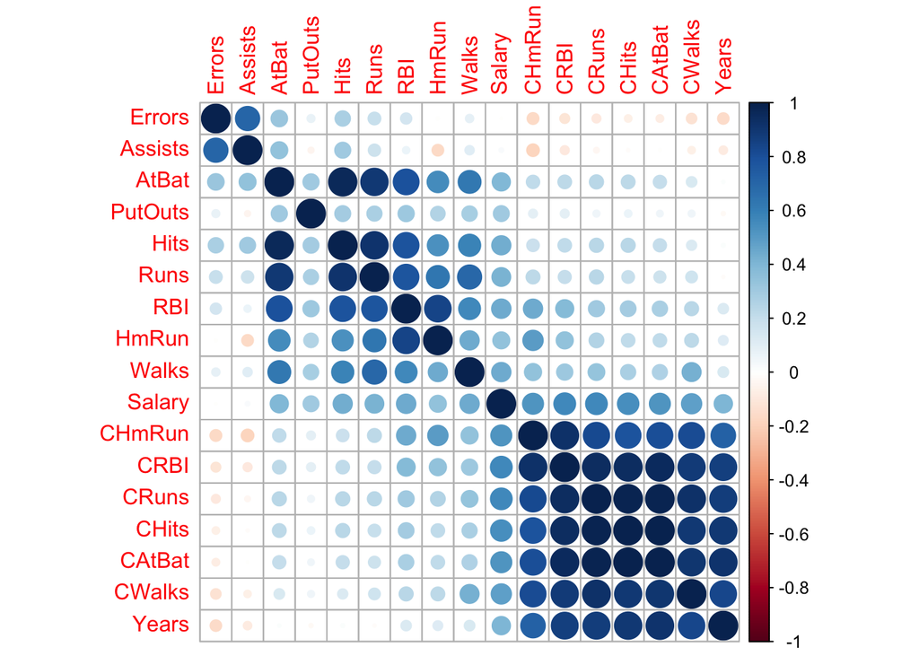

```r
library(corrplot)
df_1 = df1[ , -c(14,15,20)]
M = cor(df_1)
#corrplot.mixed(M, order = 'AOE')
corrplot(M, order = 'AOE')
```

#### Comments  
- ATBat has a strong correlation with Hits, Runs, RBI, and Walk.  
- there is a significant correlation between RBI and AtBat,Hits, Run and HmRun.  
- Variables like CRBI, CRuns, Chits, CAtBat, CWalk, and years have a strong correlation together.

## Variable Selection

### Anova Type II

```r
Anova(mlr1, type = 2)
```

|  | Sum Sq | Df | F value | Pr(>F) |
| --- | --- | --- | --- | --- |
| AtBat | 971287.622 | 1 | 9.75273015 | 0.0020076676 |
| Hits | 991241.628 | 1 | 9.95308897 | 0.0018082442 |
| HmRun | 48572.270 | 1 | 0.48771572 | 0.4856158216 |
| Runs | 63290.515 | 1 | 0.63550209 | 0.4261224977 |
| RBI | 16076.191 | 1 | 0.16142155 | 0.6882042223 |
| Walks | 1156605.687 | 1 | 11.61351478 | 0.0007662281 |
| Years | 7869.381 | 1 | 0.07901670 | 0.7788735944 |
| CAtBat | 159864.319 | 1 | 1.60520275 | 0.2063803985 |
| CHits | 3929.537 | 1 | 0.03945660 | 0.8427129019 |
| CHmRun | 1137.807 | 1 | 0.01142476 | 0.9149670939 |

[output cut: 10 more lines]

### Droping Some Variables manually

We drop variables with the lowest contribution in the model

```r
rm(list = ls())
df1 = Hitters
df1 = df1[complete.cases(df1),]
df2 = df1 [ , -c(3,4,5,7,9,10,17,18,20)]
mlr2 = lm(Salary ~ . , data = df2)
summary(mlr2)
```

```
##
## Call:
## lm(formula = Salary ~ ., data = df2)
##
## Residuals:
##     Min      1Q  Median      3Q     Max
## -901.64 -178.98  -26.72  130.38 1967.02
##
## Coefficients:
##               Estimate Std. Error t value Pr(>|t|)
## (Intercept)  116.85209   70.73807   1.652 0.099801 .
## AtBat         -1.90375    0.52301  -3.640 0.000331 ***
## Hits           6.67814    1.64590   4.057 6.62e-05 ***
## Walks          5.39152    1.59087   3.389 0.000814 ***
## CAtBat        -0.11138    0.05389  -2.067 0.039759 *
## CRuns          1.31303    0.38511   3.409 0.000758 ***
## CRBI           0.68061    0.20130   3.381 0.000837 ***
## CWalks        -0.77199    0.26289  -2.937 0.003626 **
## LeagueN       48.82127   39.97367   1.221 0.223100
## DivisionW   -113.78174   39.33427  -2.893 0.004154 **
## PutOuts        0.26984    0.07417   3.638 0.000333 ***
## ---
## Signif. codes:  0 '***' 0.001 '**' 0.01 '*' 0.05 '.' 0.1 ' ' 1
##
## Residual standard error: 312.9 on 252 degrees of freedom
## Multiple R-squared:  0.5374, Adjusted R-squared:  0.519
## F-statistic: 29.27 on 10 and 252 DF,  p-value: < 2.2e-16
```

The adjusted r-square increased from 0.5106 to 0.519 but did not change significantly

## Testing whether the present of categorical variables have significant impact on Salary or not

```r
linearHypothesis(mlr2, c("DivisionW = 0"))
```

|  | Res.Df | RSS | Df | Sum of Sq | F | Pr(>F) |
| --- | --- | --- | --- | --- | --- | --- |
| 1 | 253 | 25487134 | NA | NA | NA | NA |
| 2 | 252 | 24668034 | 1 | 819100 | 8.367638 | 0.004153536 |

```r
linearHypothesis(mlr2, c("LeagueN  = 0"))
```

|  | Res.Df | RSS | Df | Sum of Sq | F | Pr(>F) |
| --- | --- | --- | --- | --- | --- | --- |
| 1 | 253 | 24814051 | NA | NA | NA | NA |
| 2 | 252 | 24668034 | 1 | 146017.2 | 1.491661 | 0.2231003 |

## Transformation

### Using box-cox

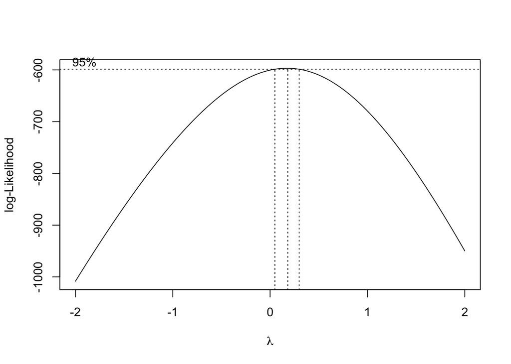

```r
library(MASS)
boxcox(mlr2)
```

```r
mlr3 <- lm((Salary)^(0.25) ~ ., data = df2)
summary(mlr3)
```

```
##
## Call:
## lm(formula = (Salary)^(0.25) ~ ., data = df2)
##
## Residuals:
##     Min      1Q  Median      3Q     Max
## -2.2502 -0.4904  0.0421  0.4258  3.3671
##
## Coefficients:
##               Estimate Std. Error t value Pr(>|t|)
## (Intercept)  3.3458623  0.1519300  22.022  < 2e-16 ***
## AtBat       -0.0034607  0.0011233  -3.081 0.002293 **
## Hits         0.0136414  0.0035350   3.859 0.000145 ***
## Walks        0.0115757  0.0034168   3.388 0.000817 ***
## CAtBat       0.0001099  0.0001157   0.950 0.343234
## CRuns        0.0011782  0.0008271   1.424 0.155557
## CRBI         0.0005637  0.0004323   1.304 0.193445
## CWalks      -0.0013025  0.0005646  -2.307 0.021878 *
## LeagueN      0.0935701  0.0858547   1.090 0.276813
## DivisionW   -0.2131271  0.0844815  -2.523 0.012260 *
## PutOuts      0.0003866  0.0001593   2.427 0.015918 *
## ---
## Signif. codes:  0 '***' 0.001 '**' 0.01 '*' 0.05 '.' 0.1 ' ' 1
##
## Residual standard error: 0.672 on 252 degrees of freedom
## Multiple R-squared:  0.5498, Adjusted R-squared:  0.5319
## F-statistic: 30.77 on 10 and 252 DF,  p-value: < 2.2e-16
```

### Transformation

We used power transformation p=0.25 for response and log transformation for `CRBI` variable

```r
mlr4 = lm(Salary^0.25 ~ AtBat + Hits + Walks + CAtBat + CRuns + log(CRBI) +
    CWalks + League + Division + PutOuts   , data = df2)
summary(mlr4)
```

```
##
## Call:
## lm(formula = Salary^0.25 ~ AtBat + Hits + Walks + CAtBat + CRuns +
##     log(CRBI) + CWalks + League + Division + PutOuts, data = df2)
##
## Residuals:
##     Min      1Q  Median      3Q     Max
## -2.0637 -0.3792 -0.0196  0.3219  4.1144
##
## Coefficients:
##               Estimate Std. Error t value Pr(>|t|)
## (Intercept)  1.6332048  0.3034827   5.382 1.69e-07 ***
## AtBat       -0.0031707  0.0010488  -3.023  0.00276 **
## Hits         0.0101516  0.0033438   3.036  0.00265 **
## Walks        0.0093572  0.0032074   2.917  0.00385 **
## CAtBat      -0.0001883  0.0001152  -1.635  0.10323
## CRuns        0.0026005  0.0007971   3.263  0.00126 **
## log(CRBI)    0.4764034  0.0756917   6.294 1.36e-09 ***
## CWalks      -0.0014534  0.0005256  -2.765  0.00611 **
## LeagueN      0.1349779  0.0802378   1.682  0.09376 .
## DivisionW   -0.1631771  0.0791438  -2.062  0.04025 *
## PutOuts      0.0004230  0.0001474   2.869  0.00447 **
## ---
## Signif. codes:  0 '***' 0.001 '**' 0.01 '*' 0.05 '.' 0.1 ' ' 1
##
## Residual standard error: 0.6268 on 252 degrees of freedom
## Multiple R-squared:  0.6083, Adjusted R-squared:  0.5928
## F-statistic: 39.14 on 10 and 252 DF,  p-value: < 2.2e-16
```

The value of adjusted R-square increased significantly to 0.5928.

## removing influential points

```r
k= ncol(df2)-1
n= nrow(df2)

which(abs(dffits(mlr4)) > 2*sqrt((k+2)/(n-k-2))) #influential if abs(dffits) > 2*sqrt((k+2)/(n-k-2))
```

```
##    -Bill Buckner   -Darrell Evans     -Glenn Davis   -Graig Nettles
##               21               55               85               92
## -Jeffrey Leonard    -Jim Sundberg    -Mike Schmidt     -Ozzie Smith
##              120              133              173              183
##       -Pete Rose  -Reggie Jackson   -Steve Balboni       -Sid Bream
##              189              201              220              222
##       -Steve Sax   -Terry Kennedy    -Wally Joyner
##              230              241              258
```

```r
which(cooks.distance(mlr4) > 1) #influential if Cook's distance > 1
```

```
## named integer(0)
```

```r
which(covratio(mlr4) > (1 + 3*(k+1)/n)) #influential if covratio > 1 + 3*(k+1)/n OR covratio < 1 - 3*(k+1)/n
```

```
##    -Bill Buckner    -Chris Speier   -Darrell Evans   -Don Mattingly
##               21               47               55               62
##  -Darrell Porter -Keith Hernandez       -Pete Rose    -Steve Garvey
##               67              140              189              226
##  -Tony Fernandez      -Wade Boggs   -Willie Upshaw
##              234              256              262
```

```r
which(covratio(mlr4) < (1 - 3*(k+1)/n))
```

```
## -Jeffrey Leonard    -Mike Schmidt     -Ozzie Smith       -Steve Sax
##              120              173              183              230
##   -Terry Kennedy
##              241
```

```r
### Finding common influential points
intersect(which(abs(dffits(mlr4)) > 2*sqrt((k+2)/(n-k-2))), which(covratio(mlr4) > (1 + 3*(k+1)/n)))
```

```
## [1]  21  55 189
```

```r
intersect(which(abs(dffits(mlr4)) > 2*sqrt((k+2)/(n-k-2))), which(covratio(mlr4) < (1 - 3*(k+1)/n)))
```

```
## [1] 120 173 183 230 241
```

#### Removing Influential Points

```r
df3 = df2[ -c(21,55,120,173,183,189,230,241), ]

mlr5 = lm(Salary^0.25 ~ AtBat + Hits + Walks + CAtBat + CRuns + log(CRBI) +
    CWalks + League + Division + PutOuts   , data = df3)
summary(mlr5)
```

```
##
## Call:
## lm(formula = Salary^0.25 ~ AtBat + Hits + Walks + CAtBat + CRuns +
##     log(CRBI) + CWalks + League + Division + PutOuts, data = df3)
##
## Residuals:
##      Min       1Q   Median       3Q      Max
## -1.60490 -0.28408  0.02481  0.29432  1.29683
##
## Coefficients:
##               Estimate Std. Error t value Pr(>|t|)
## (Intercept)  0.4513324  0.2650747   1.703 0.089905 .
## AtBat       -0.0022757  0.0008249  -2.759 0.006244 **
## Hits         0.0086190  0.0026425   3.262 0.001266 **
## Walks        0.0071524  0.0025329   2.824 0.005138 **
## CAtBat      -0.0003134  0.0000940  -3.333 0.000991 ***
## CRuns        0.0027842  0.0006403   4.348 2.02e-05 ***
## log(CRBI)    0.7165028  0.0659958  10.857  < 2e-16 ***
## CWalks      -0.0012647  0.0004395  -2.877 0.004365 **
## LeagueN      0.1309695  0.0626683   2.090 0.037664 *
## DivisionW   -0.0893950  0.0621505  -1.438 0.151613
## PutOuts      0.0003267  0.0001183   2.762 0.006173 **
## ---
## Signif. codes:  0 '***' 0.001 '**' 0.01 '*' 0.05 '.' 0.1 ' ' 1
##
## Residual standard error: 0.4802 on 244 degrees of freedom
## Multiple R-squared:  0.7625, Adjusted R-squared:  0.7528
## F-statistic: 78.34 on 10 and 244 DF,  p-value: < 2.2e-16
```

### Adjusted R-Square

For the final model the value of adjusted R-square increased significantly to 0.7528.

### Linearity Assumptions

#### Checking for zero mean and constant variance of error terms

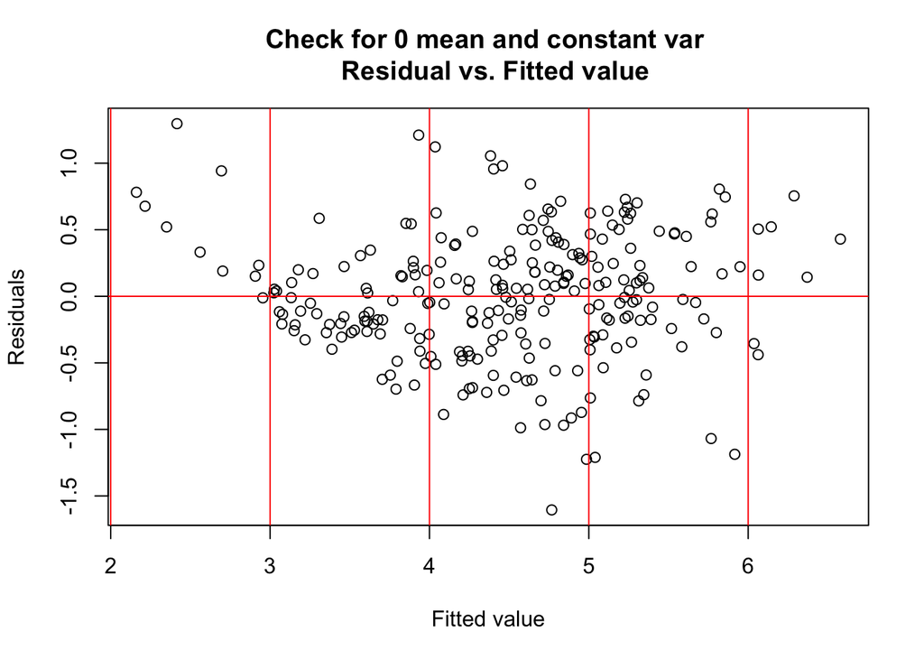

```r
plot(mlr5$fitted.values, mlr5$residuals,
     xlab = "Fitted value",
     ylab = "Residuals",
     main = "Check for 0 mean and constant var \n  Residual vs. Fitted value")
list1 = seq(2,7,1)
abline(h=0, v = list1, col="red")
```